# Mid-term Programming with data assignment

## Premier League Football Analysis

### Introduction

For this assignment, we decided to review the available historical data from British Premier League football. Our main objective is to analyse individual game statistics and their relationship with the game results. We will try to find a good prediction model that can be used for making predictions based on this data. We will also investigate which betting companies odds correlate the best with the final game results.

### Description of data set

There are several available online sources for relevant statistics that are suitable for this type of project, but we are interested in those sources that contain the most detailed individual statistics for each match of the season. We used data from two online sources, cleaned the data and then combined it into one data set.

The source of data:

https://www.football-data.co.uk/englandm.php

https://footystats.org/download-stats-csv#

Both datasets can be downloaded in CSV format with accompanying notes on the column names. We chose to analyse the data from 2018/2019 season, but the data from other seasons would also fit into our data project.

```python
# importing Python's data analytics libraries

import pandas as pd
import numpy as np
import seaborn as sb
import matplotlib.pyplot as plt
from sklearn import linear_model
from sklearn.model_selection import train_test_split
from sklearn.metrics import confusion_matrix
import statsmodels.api as sm
from sklearn import metrics
```

Source data files are located in the "./data/" directory.

```python
# load both datasets into two separate dataframes.
df1 = pd.read_csv('data/england-premier-league-matches-2018-to-2019-stats.csv')
df2 = pd.read_csv('data/E0.csv')
df2.shape
```

```
(380, 62)
```

### Data selection

We have imported two separate datasets from which, we would like to extract those features that will be relevant in our analysis.

- There are 380 entries in both datasets that corresponding to the number of matches in the 2018/19 EPL season.
- The first dataset contains data about each game of that season with statistics such as ball possession, shots on target or card statistics.
- The second dataset includes additional data such as betting odds of individual bookmakers.

Here we specify the columns we would like to have in each data set and then pass both lists to the DataFrame object.

```python
# columns containing match statistics
cols_df1 = ['date_GMT','home_team_name','away_team_name', 'home_team_goal_count','away_team_goal_count','home_team_goal_count_half_time',
        'away_team_goal_count_half_time', 'home_team_goal_timings','away_team_goal_timings','home_team_corner_count','away_team_corner_count',
        'home_team_yellow_cards','home_team_red_cards','away_team_yellow_cards','away_team_red_cards','home_team_first_half_cards','home_team_second_half_cards',
        'away_team_first_half_cards','away_team_second_half_cards','home_team_shots','away_team_shots','home_team_shots_on_target','away_team_shots_on_target',
        'home_team_fouls','away_team_fouls','home_team_possession','away_team_possession','average_goals_per_match_pre_match','btts_percentage_pre_match','average_corners_per_match_pre_match',
        'average_cards_per_match_pre_match']

# columns containing betting odds data
cols_df2 = ['Date', 'HomeTeam', 'AwayTeam','B365H', 'B365D', 'B365A', 'BWH', 'BWD',
       'BWA', 'IWH', 'IWD', 'IWA', 'PSH', 'PSD', 'PSA', 'WHH', 'WHD', 'WHA',
       'VCH', 'VCD', 'VCA','PSCH', 'PSCD', 'PSCA']
```

```python
# creating two separate dataframes
df1 = df1[cols_df1]
df2 = df2[cols_df2]
```

### Data cleaning

For better manipulation with the datetime objects, we convert the dates form both datasets to the Pandas datetime format.

```python
# converting between different date formats
df1['date_GMT'] = pd.to_datetime(df1['date_GMT'])
df2['Date'] = pd.to_datetime(df2['Date'], format='%d/%m/%Y')
```

There are also inconsistencies in the club names inside both dataframes. We harmonise the club names in both sets.

```python
# list of unique club names from the first dataset
df1['home_team_name'].unique()
```

```
array(['Manchester United', 'Newcastle United', 'AFC Bournemouth',
       'Fulham', 'Huddersfield Town', 'Watford',
       'Wolverhampton Wanderers', 'Liverpool', 'Southampton', 'Arsenal',
       'Cardiff City', 'Everton', 'Leicester City', 'Tottenham Hotspur',
       'West Ham United', 'Chelsea', 'Burnley', 'Manchester City',
       'Brighton & Hove Albion', 'Crystal Palace'], dtype=object)
```

```python
# list of unique club names from the second dataset
df2['HomeTeam'].unique()
```

```
array(['Man United', 'Bournemouth', 'Fulham', 'Huddersfield', 'Newcastle',
       'Watford', 'Wolves', 'Arsenal', 'Liverpool', 'Southampton',
       'Cardiff', 'Chelsea', 'Everton', 'Leicester', 'Tottenham',
       'West Ham', 'Brighton', 'Burnley', 'Man City', 'Crystal Palace'],
      dtype=object)
```

We create a dictionary that maps the club names from first dataframe to the second.

```python
teams = {'Man United': 'Manchester United',
         'Bournemouth': 'AFC Bournemouth',
         'Fulham': 'Fulham',
         'Huddersfield': 'Huddersfield Town',
         'Newcastle': 'Newcastle United',
         'Watford': 'Watford',
         'Wolves': 'Wolverhampton Wanderers',
         'Arsenal': 'Arsenal',
         'Liverpool':'Liverpool',
         'Southampton':'Southampton',
         'Cardiff': 'Cardiff City',
         'Chelsea': 'Chelsea',
         'Everton': 'Everton',
         'Leicester': 'Leicester City',
         'Tottenham': 'Tottenham Hotspur',
         'West Ham': 'West Ham United',
         'Brighton': 'Brighton & Hove Albion',
         'Burnley': 'Burnley',
         'Man City': 'Manchester City',
         'Crystal Palace':'Crystal Palace'}
```

```python
# Here we map the club names from df1 to df2
df2['HomeTeam'] = df2['HomeTeam'].map(teams)
df2['AwayTeam'] = df2['AwayTeam'].map(teams)

df2['HomeTeam'].unique()
```

```
array(['Manchester United', 'AFC Bournemouth', 'Fulham',
       'Huddersfield Town', 'Newcastle United', 'Watford',
       'Wolverhampton Wanderers', 'Arsenal', 'Liverpool', 'Southampton',
       'Cardiff City', 'Chelsea', 'Everton', 'Leicester City',
       'Tottenham Hotspur', 'West Ham United', 'Brighton & Hove Albion',
       'Burnley', 'Manchester City', 'Crystal Palace'], dtype=object)
```

```python
df2['AwayTeam'].unique()
```

```
array(['Leicester City', 'Cardiff City', 'Crystal Palace', 'Chelsea',
       'Tottenham Hotspur', 'Brighton & Hove Albion', 'Everton',
       'Manchester City', 'West Ham United', 'Burnley',
       'Newcastle United', 'Arsenal', 'Southampton',
       'Wolverhampton Wanderers', 'Fulham', 'AFC Bournemouth',
       'Manchester United', 'Watford', 'Huddersfield Town', 'Liverpool'],
      dtype=object)
```

### Creating a unique keys

We would like to join both dataframes on each game entry that is unique in each dataframe. For this purpose, we have to create unique keys that can be used for merging both dataframes. One way of doing this is to concatenate strings from multiple columns of each dataframe and create a string that would be unique for each entry. Concatenation of strings from columns such as date, home team name and away team name, will create those unique keys. I decided for the combination of the first 10 letters from the date column with the first three letters of home and away team name. That will create a unique key for each match of the season and could be used for joining both dataframes.

```python
# Creating of unique ID for each game of the season
df1['date_str'] = df1['date_GMT'].dt.strftime('%Y-%m-%d')
df1['id']=df1['date_str'].str[:10]+df1['home_team_name'].str[:3]+df1['away_team_name'].str[:3]

df2['date_str'] = df2['Date'].dt.strftime('%Y-%m-%d')
df2['id'] = df2['date_str'].str[:10]+df2['HomeTeam'].str[:3]+df2['AwayTeam'].str[:3]

# Let's check if the number of unique keys in both dataframes are equal
df1['id'].unique().size == df2['id'].unique().size == df1['date_GMT'].size
```

```
True
```

```python
# Here we merge two dataframes into the main dataframe with all relevant columns that will be later used in our analysis.
df = pd.merge(left=df1, right=df2, left_on='id', right_on='id')
df = df.drop(df.loc[:, 'date_str_x':'AwayTeam'].columns, axis = 1)
df.info()
```

```
<class 'pandas.core.frame.DataFrame'>
Int64Index: 380 entries, 0 to 379
Data columns (total 53 columns):
 #   Column                               Non-Null Count  Dtype
---  ------                               --------------  -----
 0   date_GMT                             380 non-null    datetime64[ns]
 1   home_team_name                       380 non-null    object
 2   away_team_name                       380 non-null    object
 3   home_team_goal_count                 380 non-null    int64
 4   away_team_goal_count                 380 non-null    int64
 5   home_team_goal_count_half_time       380 non-null    int64
 6   away_team_goal_count_half_time       380 non-null    int64
 7   home_team_goal_timings               292 non-null    object
 8   away_team_goal_timings               261 non-null    object
 9   home_team_corner_count               380 non-null    int64
```

[output cut: 45 more lines]

### Data Exploration

For example, when we want to know the start date of the season, we can simply call:

```python
season_start = df['date_GMT'].min()
season_start
```

```
Timestamp('2018-08-10 19:00:00')
```

We can also get the information about the length of the whole season:

```python
season_end = df['date_GMT'].max()
season_length = season_end - season_start
season_length
```

```
Timedelta('274 days 19:00:00')
```

Now, when our dataset is prepared, we can filter key stats on each game of our favourite team.

```python
# A function that will return the table with all games of the given team
def get_stats(fav_team):
    newdf = df[(df.home_team_name == fav_team) | (df.away_team_name == fav_team) ]
    newdf= newdf.reset_index(drop=True)
    newdf.index = newdf.index + 1
    return newdf

get_stats("Arsenal")
```

|  | date_GMT | home_team_name | away_team_name | home_team_goal_count | away_team_goal_count | home_team_goal_count_half_time | away_team_goal_count_half_time | home_team_goal_timings | away_team_goal_timings | home_team_corner_count | ... | WHH | WHD | WHA | VCH | VCD | VCA | PSCH | PSCD | PSCA | date_str_y |
| --- | --- | --- | --- | --- | --- | --- | --- | --- | --- | --- | --- | --- | --- | --- | --- | --- | --- | --- | --- | --- | --- |
| 1 | 2018-08-12 15:00:00 | Arsenal | Manchester City | 0 | 2 | 0 | 1 | NaN | 14,64 | 2 | ... | 3.80 | 3.80 | 1.91 | 3.90 | 4.00 | 1.91 | 4.43 | 4.13 | 1.81 | 2018-08-12 |
| 2 | 2018-08-18 16:30:00 | Chelsea | Arsenal | 3 | 2 | 2 | 2 | 9,20,81 | 37,41 | 5 | ... | 1.83 | 3.75 | 4.00 | 1.80 | 4.00 | 4.50 | 1.83 | 3.84 | 4.64 | 2018-08-18 |
| 3 | 2018-08-25 14:00:00 | Arsenal | West Ham United | 3 | 1 | 1 | 1 | 30,70,90'2 | 25 | 7 | ... | 1.36 | 5.00 | 7.50 | 1.36 | 5.50 | 9.00 | 1.37 | 5.65 | 8.67 | 2018-08-25 |
| 4 | 2018-09-02 12:30:00 | Cardiff City | Arsenal | 2 | 3 | 1 | 1 | 45'2,70 | 11,62,81 | 3 | ... | 5.50 | 4.33 | 1.53 | 6.50 | 4.33 | 1.55 | 6.34 | 4.47 | 1.56 | 2018-09-02 |
| 5 | 2018-09-15 14:00:00 | Newcastle United | Arsenal | 1 | 2 | 0 | 0 | 90'1 | 49,58 | 10 | ... | 3.75 | 3.70 | 1.91 | 4.10 | 3.75 | 1.95 | 4.46 | 3.86 | 1.86 | 2018-09-15 |
| 6 | 2018-09-23 15:00:00 | Arsenal | Everton | 2 | 0 | 0 | 0 | 56,59 | NaN | 5 | ... | 1.47 | 4.75 | 6.00 | 1.45 | 5.00 | 7.00 | 1.40 | 5.46 | 7.94 | 2018-09-23 |
| 7 | 2018-09-29 14:00:00 | Arsenal | Watford | 2 | 0 | 0 | 0 | 81,83 | NaN | 6 | ... | 1.44 | 5.00 | 6.00 | 1.50 | 4.80 | 6.50 | 1.49 | 4.88 | 6.75 | 2018-09-29 |
| 8 | 2018-10-07 11:00:00 | Fulham | Arsenal | 1 | 5 | 1 | 1 | 44 | 29,49,67,79,90'1 | 4 | ... | 4.40 | 4.20 | 1.70 | 5.00 | 4.40 | 1.67 | 5.01 | 4.48 | 1.67 | 2018-10-07 |
| 9 | 2018-10-22 19:00:00 | Arsenal | Leicester City | 3 | 1 | 1 | 1 | 45,63,66 | 31 | 6 | ... | 1.53 | 4.33 | 5.80 | 1.53 | 4.60 | 6.25 | 1.63 | 4.13 | 6.03 | 2018-10-22 |
| 10 | 2018-10-28 13:30:00 | Crystal Palace | Arsenal | 2 | 2 | 1 | 0 | 45'1,83 | 51,56 | 6 | ... | 4.20 | 4.20 | 1.75 | 4.75 | 4.10 | 1.73 | 4.57 | 3.86 | 1.84 | 2018-10-28 |
| 11 | 2018-11-03 17:30:00 | Arsenal | Liverpool | 1 | 1 | 0 | 0 | 82 | 61 | 5 | ... | 3.60 | 3.70 | 2.00 | 3.80 | 3.80 | 2.00 | 3.91 | 3.94 | 1.96 | 2018-11-03 |
| 12 | 2018-11-11 16:30:00 | Arsenal | Wolverhampton Wanderers | 1 | 1 | 0 | 1 | 86 | 13 | 11 | ... | 1.65 | 4.20 | 4.75 | 1.67 | 4.20 | 5.25 | 1.65 | 4.15 | 5.71 | 2018-11-11 |
| 13 | 2018-11-25 13:30:00 | AFC Bournemouth | Arsenal | 1 | 2 | 1 | 1 | 45'1 | 30,67 | 5 | ... | 3.50 | 3.80 | 2.00 | 3.50 | 3.90 | 2.05 | 3.38 | 3.70 | 2.21 | 2018-11-25 |
| 14 | 2018-12-02 14:05:00 | Arsenal | Tottenham Hotspur | 4 | 2 | 1 | 2 | 10,56,74,77 | 30,34 | 8 | ... | 2.55 | 3.50 | 2.62 | 2.55 | 3.60 | 2.75 | 2.94 | 3.53 | 2.53 | 2018-12-02 |
| 15 | 2018-12-05 20:00:00 | Manchester United | Arsenal | 2 | 2 | 1 | 1 | 30,69 | 26,68 | 4 | ... | 2.38 | 3.50 | 2.90 | 2.45 | 3.50 | 2.90 | 2.44 | 3.52 | 3.07 | 2018-12-05 |
| 16 | 2018-12-08 15:00:00 | Arsenal | Huddersfield Town | 1 | 0 | 0 | 0 | 83 | NaN | 7 | ... | 1.25 | 6.00 | 12.00 | 1.29 | 6.00 | 13.00 | 1.30 | 5.74 | 12.40 | 2018-12-08 |
| 17 | 2018-12-16 13:30:00 | Southampton | Arsenal | 3 | 2 | 2 | 1 | 20,44,85 | 28,53 | 4 | ... | 3.90 | 3.75 | 1.91 | 4.00 | 3.90 | 1.95 | 4.52 | 4.00 | 1.82 | 2018-12-16 |
| 18 | 2018-12-22 12:30:00 | Arsenal | Burnley | 3 | 1 | 1 | 0 | 14,48,90'1 | 63 | 1 | ... | 1.22 | 6.00 | 15.00 | 1.25 | 6.50 | 15.00 | 1.20 | 7.15 | 15.42 | 2018-12-22 |
| 19 | 2018-12-26 17:15:00 | Brighton & Hove Albion | Arsenal | 1 | 1 | 1 | 1 | 35 | 7 | 4 | ... | 5.00 | 3.80 | 1.70 | 5.25 | 3.90 | 1.75 | 5.48 | 3.89 | 1.72 | 2018-12-26 |
| 20 | 2018-12-29 17:30:00 | Liverpool | Arsenal | 5 | 1 | 4 | 1 | 14,16,32,45'2,65 | 11 | 5 | ... | 1.47 | 4.75 | 6.50 | 1.50 | 4.80 | 7.00 | 1.39 | 5.54 | 7.97 | 2018-12-29 |
| 21 | 2019-01-01 15:00:00 | Arsenal | Fulham | 4 | 1 | 1 | 0 | 25,55,79,83 | 69 | 8 | ... | 1.32 | 5.25 | 9.50 | 1.36 | 5.50 | 10.00 | 1.39 | 5.24 | 8.13 | 2019-01-01 |
| 22 | 2019-01-12 12:30:00 | West Ham United | Arsenal | 1 | 0 | 0 | 0 | 48 | NaN | 7 | ... | 3.40 | 3.80 | 2.00 | 3.40 | 4.00 | 2.10 | 3.58 | 3.95 | 2.05 | 2019-01-12 |
| 23 | 2019-01-19 17:30:00 | Arsenal | Chelsea | 2 | 0 | 2 | 0 | 14,39 | NaN | 5 | ... | 3.00 | 3.50 | 2.30 | 3.10 | 3.60 | 2.38 | 3.36 | 3.49 | 2.30 | 2019-01-19 |
| 24 | 2019-01-29 19:45:00 | Arsenal | Cardiff City | 2 | 1 | 0 | 0 | 66,83 | 90'3 | 4 | ... | 1.20 | 6.00 | 15.00 | 1.22 | 7.00 | 15.00 | 1.22 | 6.98 | 13.34 | 2019-01-29 |
| 25 | 2019-02-03 16:30:00 | Manchester City | Arsenal | 3 | 1 | 2 | 1 | 1,44,61 | 11 | 4 | ... | 1.29 | 6.00 | 9.50 | 1.30 | 6.25 | 9.00 | 1.26 | 7.19 | 10.35 | 2019-02-03 |
| 26 | 2019-02-09 15:00:00 | Huddersfield Town | Arsenal | 1 | 2 | 0 | 2 | 90'3 | 16,44 | 5 | ... | 5.80 | 4.20 | 1.60 | 6.00 | 4.20 | 1.62 | 5.65 | 3.99 | 1.67 | 2019-02-09 |
| 27 | 2019-02-24 14:05:00 | Arsenal | Southampton | 2 | 0 | 2 | 0 | 6,17 | NaN | 6 | ... | 1.50 | 4.33 | 6.50 | 1.53 | 4.60 | 6.50 | 1.58 | 4.14 | 6.61 | 2019-02-24 |
| 28 | 2019-02-27 19:45:00 | Arsenal | AFC Bournemouth | 5 | 1 | 2 | 1 | 4,27,47,59,78 | 30 | 9 | ... | 1.42 | 4.75 | 7.50 | 1.45 | 5.00 | 7.50 | 1.40 | 5.22 | 8.05 | 2019-02-27 |
| 29 | 2019-03-02 12:30:00 | Tottenham Hotspur | Arsenal | 1 | 1 | 0 | 1 | 74 | 16 | 3 | ... | 2.00 | 3.60 | 3.70 | 2.05 | 3.70 | 3.70 | 2.02 | 3.59 | 4.07 | 2019-03-02 |
| 30 | 2019-03-10 16:30:00 | Arsenal | Manchester United | 2 | 0 | 1 | 0 | 12,69 | NaN | 5 | ... | 2.38 | 3.50 | 2.90 | 2.45 | 3.60 | 2.90 | 2.42 | 3.54 | 3.09 | 2019-03-10 |
| 31 | 2019-04-01 19:00:00 | Arsenal | Newcastle United | 2 | 0 | 1 | 0 | 30,83 | NaN | 6 | ... | 1.36 | 5.00 | 8.50 | 1.40 | 5.00 | 8.50 | 1.46 | 4.66 | 8.19 | 2019-04-01 |
| 32 | 2019-04-07 13:05:00 | Everton | Arsenal | 1 | 0 | 1 | 0 | 10 | NaN | 9 | ... | 3.00 | 3.50 | 2.30 | 3.10 | 3.60 | 2.38 | 2.82 | 3.60 | 2.59 | 2019-04-07 |
| 33 | 2019-04-15 19:00:00 | Watford | Arsenal | 0 | 1 | 0 | 1 | NaN | 10 | 6 | ... | 3.10 | 3.70 | 2.20 | 3.25 | 3.75 | 2.20 | 3.63 | 3.74 | 2.09 | 2019-04-15 |
| 34 | 2019-04-21 15:00:00 | Arsenal | Crystal Palace | 2 | 3 | 0 | 1 | 47,77 | 17,61,69 | 8 | ... | 1.52 | 4.33 | 6.50 | 1.53 | 4.40 | 6.50 | 1.52 | 4.70 | 6.55 | 2019-04-21 |
| 35 | 2019-04-24 18:45:00 | Wolverhampton Wanderers | Arsenal | 3 | 1 | 3 | 0 | 28,37,45'2 | 80 | 5 | ... | 2.88 | 3.40 | 2.45 | 3.00 | 3.40 | 2.55 | 2.77 | 3.45 | 2.72 | 2019-04-24 |
| 36 | 2019-04-28 11:00:00 | Leicester City | Arsenal | 3 | 0 | 0 | 0 | 59,86,90'5 | NaN | 8 | ... | 2.62 | 3.60 | 2.55 | 2.75 | 3.60 | 2.55 | 2.60 | 3.65 | 2.77 | 2019-04-28 |
| 37 | 2019-05-05 15:30:00 | Arsenal | Brighton & Hove Albion | 1 | 1 | 1 | 0 | 9 | 61 | 16 | ... | 1.40 | 4.60 | 8.50 | 1.40 | 4.80 | 8.50 | 1.27 | 6.31 | 12.29 | 2019-05-05 |
| 38 | 2019-05-12 14:00:00 | Burnley | Arsenal | 1 | 3 | 0 | 0 | 65 | 52,63,90'4 | 4 | ... | 3.10 | 3.70 | 2.20 | 3.13 | 3.80 | 2.20 | 2.52 | 3.69 | 2.80 | 2019-05-12 |

38 rows × 53 columns

We can also aggregate the data and create the table with all teams ranked according to their total points scored for whole season.

```python
# To do this, first we have to calculate points for each game, because our dataframe doesn't contain the data about scored points.
# In our original data set, we only had information about the goals scored by each team in each game, so we create a function to calculate the game points.
# Three points are awarded for a win, one point for a draw and none for a defeat.

def calculate_points(x,y):
    if(x > y):
        return 3
    elif(x==y):
        return 1
    else:
        return 0

# We then apply this function on each row of the dataframe.
df['home_team_points'] = df.apply(lambda row : calculate_points(row['home_team_goal_count'],row['away_team_goal_count']), axis = 1)
df['away_team_points'] = df.apply(lambda row : calculate_points(row['away_team_goal_count'],row['home_team_goal_count']), axis = 1)

# We can check the calculation on the sample data.
df[['home_team_name','away_team_name','home_team_goal_count','away_team_goal_count','home_team_points','away_team_points']].head()
```

|  | home_team_name | away_team_name | home_team_goal_count | away_team_goal_count | home_team_points | away_team_points |
| --- | --- | --- | --- | --- | --- | --- |
| 0 | Manchester United | Leicester City | 2 | 1 | 3 | 0 |
| 1 | Newcastle United | Tottenham Hotspur | 1 | 2 | 0 | 3 |
| 2 | AFC Bournemouth | Cardiff City | 2 | 0 | 3 | 0 |
| 3 | Fulham | Crystal Palace | 0 | 2 | 0 | 3 |
| 4 | Huddersfield Town | Chelsea | 0 | 3 | 0 | 3 |

```python
# For each game, we also add the information of full time result (H=Home Win, D=Draw, A=Away Win).
def calculate_result(x, y):
    if x==y:
        return 'D'
    elif x>y:
        return 'H'
    else:
        return 'A'

df["full_time_result"] = df.apply(lambda row : calculate_result(row['home_team_goal_count'],row['away_team_goal_count']), axis = 1)

df[['home_team_name','away_team_name','home_team_goal_count','away_team_goal_count','home_team_points','away_team_points','full_time_result']].head()
```

|  | home_team_name | away_team_name | home_team_goal_count | away_team_goal_count | home_team_points | away_team_points | full_time_result |
| --- | --- | --- | --- | --- | --- | --- | --- |
| 0 | Manchester United | Leicester City | 2 | 1 | 3 | 0 | H |
| 1 | Newcastle United | Tottenham Hotspur | 1 | 2 | 0 | 3 | A |
| 2 | AFC Bournemouth | Cardiff City | 2 | 0 | 3 | 0 | H |
| 3 | Fulham | Crystal Palace | 0 | 2 | 0 | 3 | A |
| 4 | Huddersfield Town | Chelsea | 0 | 3 | 0 | 3 | A |

Next, we aggregate the game results and create the final table with scored points.

```python
# This function sums the total score of a given team.
def get_final_score(team):
    home_score = df[(df.home_team_name == team)]['home_team_points'].sum()
    away_score = df[(df.away_team_name == team)]['away_team_points'].sum()
    total_score = home_score + away_score
    return total_score

get_final_score("Arsenal")
```

```
70
```

```python
# This function computes the number of games played by a given team.
def count_games_played(team):
    home_played = df[(df.home_team_name == team)]["home_team_name"].count()
    away_played = df[(df.away_team_name == team)]["away_team_name"].count()
    return home_played + away_played

count_games_played("Arsenal")
```

```
38
```

```python
# This function computes the number of wins of a given team.
def count_total_wins(team):
    home_wins = df[(df.home_team_name == team)&(df.full_time_result == "H")]["home_team_name"].count()
    away_wins = df[(df.away_team_name == team)&(df.full_time_result == "A")]["away_team_name"].count()
    return home_wins + away_wins

count_total_wins("Arsenal")
```

```
21
```

```python
# This function computes the number of losses of a given team.
def count_total_losses(team):
    home_lost = df[(df.home_team_name == team)&(df.full_time_result == "A")]["home_team_name"].count()
    away_lost = df[(df.away_team_name == team)&(df.full_time_result == "H")]["away_team_name"].count()
    return home_lost + away_lost

count_total_losses("Arsenal")
```

```
10
```

```python
# This function computes the number of drawns of a given team.
def count_total_draws(team):
    home_draws = df[(df.home_team_name == team)&(df.full_time_result == "D")]["home_team_name"].count()
    away_draws = df[(df.away_team_name == team)&(df.full_time_result == "D")]["away_team_name"].count()
    return home_draws + away_draws

count_total_draws("Arsenal")
```

```
7
```

```python
# For the resulting dataframe we create the list of teams with aggregated team's results.
teams = np.unique(df[['home_team_name', 'away_team_name']].values)
league_table_list = []
for team in teams:
    league_table_list.append((team, count_games_played(team), count_total_wins(team), count_total_draws(team), count_total_losses(team), get_final_score(team)))

league_table_list
```

```
[('AFC Bournemouth', 38, 13, 6, 19, 45),
 ('Arsenal', 38, 21, 7, 10, 70),
 ('Brighton & Hove Albion', 38, 9, 9, 20, 36),
 ('Burnley', 38, 11, 7, 20, 40),
 ('Cardiff City', 38, 10, 4, 24, 34),
 ('Chelsea', 38, 21, 9, 8, 72),
 ('Crystal Palace', 38, 14, 7, 17, 49),
 ('Everton', 38, 15, 9, 14, 54),
 ('Fulham', 38, 7, 5, 26, 26),
 ('Huddersfield Town', 38, 3, 7, 28, 16),
 ('Leicester City', 38, 15, 7, 16, 52),
 ('Liverpool', 38, 30, 7, 1, 97),
 ('Manchester City', 38, 32, 2, 4, 98),
 ('Manchester United', 38, 19, 9, 10, 66),
 ('Newcastle United', 38, 12, 9, 17, 45),
 ('Southampton', 38, 9, 12, 17, 39),
 ('Tottenham Hotspur', 38, 23, 2, 13, 71),
 ('Watford', 38, 14, 8, 16, 50),
 ('West Ham United', 38, 15, 7, 16, 52),
 ('Wolverhampton Wanderers', 38, 16, 9, 13, 57)]
```

```python
# Finally, we feed this list of tuples into the dataframe and sort the table by scoring points.
league_table_df = pd.DataFrame(league_table_list,columns = ['Club', 'Played','Won', 'Draws', 'Losses', 'Points']).sort_values(by=['Points'],ascending=False)
league_table_df = league_table_df.reset_index(drop=True)
league_table_df.index += 1
league_table_df
```

|  | Club | Played | Won | Draws | Losses | Points |
| --- | --- | --- | --- | --- | --- | --- |
| 1 | Manchester City | 38 | 32 | 2 | 4 | 98 |
| 2 | Liverpool | 38 | 30 | 7 | 1 | 97 |
| 3 | Chelsea | 38 | 21 | 9 | 8 | 72 |
| 4 | Tottenham Hotspur | 38 | 23 | 2 | 13 | 71 |
| 5 | Arsenal | 38 | 21 | 7 | 10 | 70 |
| 6 | Manchester United | 38 | 19 | 9 | 10 | 66 |
| 7 | Wolverhampton Wanderers | 38 | 16 | 9 | 13 | 57 |
| 8 | Everton | 38 | 15 | 9 | 14 | 54 |
| 9 | West Ham United | 38 | 15 | 7 | 16 | 52 |
| 10 | Leicester City | 38 | 15 | 7 | 16 | 52 |
| 11 | Watford | 38 | 14 | 8 | 16 | 50 |
| 12 | Crystal Palace | 38 | 14 | 7 | 17 | 49 |
| 13 | Newcastle United | 38 | 12 | 9 | 17 | 45 |
| 14 | AFC Bournemouth | 38 | 13 | 6 | 19 | 45 |
| 15 | Burnley | 38 | 11 | 7 | 20 | 40 |
| 16 | Southampton | 38 | 9 | 12 | 17 | 39 |
| 17 | Brighton & Hove Albion | 38 | 9 | 9 | 20 | 36 |
| 18 | Cardiff City | 38 | 10 | 4 | 24 | 34 |
| 19 | Fulham | 38 | 7 | 5 | 26 | 26 |
| 20 | Huddersfield Town | 38 | 3 | 7 | 28 | 16 |

# Data Analysis

## Part 1

In the first part of the analysis, we will investigate which betting companies odds correlate the best with the final game results.

In the second part, we will analyse the relationships between individual game statistics and the final game results.

```python
# Here, we create a correlation matrix of Pearson's correlation coefficient.
# Value of + 1 is total positive correlation, 0 is no linear correlation, - 1 is total negative linear correlation.

# We select the columns relevant to the analysis of betting odds and create a new dataframe

cols_bets = ['home_team_name','away_team_name','home_team_points', 'away_team_points','home_team_goal_count','away_team_goal_count',
        'B365H', 'B365D', 'B365A', 'BWH', 'BWD','BWA', 'IWH', 'IWD', 'IWA', 'PSH', 'PSD', 'PSA',
        'WHH', 'WHD', 'WHA','VCH', 'VCD', 'VCA','PSCH', 'PSCD', 'PSCA']

df_bets = df[cols_bets].copy()
```

```python
df_bets
```

|  | home_team_name | away_team_name | home_team_points | away_team_points | home_team_goal_count | away_team_goal_count | B365H | B365D | B365A | BWH | ... | PSA | WHH | WHD | WHA | VCH | VCD | VCA | PSCH | PSCD | PSCA |
| --- | --- | --- | --- | --- | --- | --- | --- | --- | --- | --- | --- | --- | --- | --- | --- | --- | --- | --- | --- | --- | --- |
| 0 | Manchester United | Leicester City | 3 | 0 | 2 | 1 | 1.57 | 3.90 | 7.50 | 1.53 | ... | 7.50 | 1.57 | 3.80 | 6.00 | 1.57 | 4.00 | 7.00 | 1.55 | 4.07 | 7.69 |
| 1 | Newcastle United | Tottenham Hotspur | 0 | 3 | 1 | 2 | 3.90 | 3.50 | 2.04 | 3.80 | ... | 2.08 | 3.80 | 3.20 | 2.05 | 3.90 | 3.40 | 2.10 | 4.74 | 3.53 | 1.89 |
| 2 | AFC Bournemouth | Cardiff City | 3 | 0 | 2 | 0 | 1.90 | 3.60 | 4.50 | 1.90 | ... | 4.58 | 1.91 | 3.50 | 4.00 | 1.87 | 3.60 | 4.75 | 1.88 | 3.61 | 4.70 |
| 3 | Fulham | Crystal Palace | 0 | 3 | 0 | 2 | 2.50 | 3.40 | 3.00 | 2.45 | ... | 3.00 | 2.45 | 3.30 | 2.80 | 2.50 | 3.40 | 3.00 | 2.62 | 3.38 | 2.90 |
| 4 | Huddersfield Town | Chelsea | 0 | 3 | 0 | 3 | 6.50 | 4.00 | 1.61 | 6.25 | ... | 1.62 | 5.80 | 3.90 | 1.57 | 6.50 | 4.00 | 1.62 | 7.24 | 3.95 | 1.58 |
| ... | ... | ... | ... | ... | ... | ... | ... | ... | ... | ... | ... | ... | ... | ... | ... | ... | ... | ... | ... | ... | ... |
| 375 | Liverpool | Wolverhampton Wanderers | 3 | 0 | 2 | 0 | 1.30 | 6.00 | 11.00 | 1.30 | ... | 10.54 | 1.29 | 5.50 | 11.00 | 1.30 | 5.75 | 11.50 | 1.32 | 5.89 | 9.48 |
| 376 | Manchester United | Cardiff City | 0 | 3 | 0 | 2 | 1.28 | 6.50 | 11.00 | 1.25 | ... | 10.21 | 1.25 | 6.50 | 10.00 | 1.29 | 6.25 | 11.00 | 1.30 | 6.06 | 9.71 |
| 377 | Southampton | Huddersfield Town | 1 | 1 | 1 | 1 | 1.44 | 4.75 | 8.50 | 1.42 | ... | 7.62 | 1.40 | 4.75 | 8.00 | 1.40 | 4.80 | 8.50 | 1.37 | 5.36 | 8.49 |
| 378 | Tottenham Hotspur | Everton | 1 | 1 | 2 | 2 | 2.20 | 3.50 | 3.50 | 2.10 | ... | 3.64 | 2.10 | 3.50 | 3.50 | 2.10 | 3.50 | 3.70 | 1.91 | 3.81 | 4.15 |
| 379 | Watford | West Ham United | 0 | 3 | 1 | 4 | 2.25 | 3.75 | 3.20 | 2.20 | ... | 3.21 | 2.20 | 3.70 | 3.10 | 2.20 | 3.75 | 3.25 | 2.11 | 3.86 | 3.41 |

380 rows × 27 columns

For the purpose of the analysis, we convert individual scores into adjusted probability rates due to the inverse relationship of rates and points.

```python
cols = ['B365H', 'B365D', 'B365A', 'BWH', 'BWD','BWA', 'IWH', 'IWD', 'IWA', 'PSH', 'PSD', 'PSA',
        'WHH', 'WHD', 'WHA','VCH', 'VCD', 'VCA','PSCH', 'PSCD', 'PSCA']
```

```python
# We convert values in selected columns to reciprocals
df_bets[cols]=1/df_bets[cols]
```

```python
df_bets
```

|  | home_team_name | away_team_name | home_team_points | away_team_points | home_team_goal_count | away_team_goal_count | B365H | B365D | B365A | BWH | ... | PSA | WHH | WHD | WHA | VCH | VCD | VCA | PSCH | PSCD | PSCA |
| --- | --- | --- | --- | --- | --- | --- | --- | --- | --- | --- | --- | --- | --- | --- | --- | --- | --- | --- | --- | --- | --- |
| 0 | Manchester United | Leicester City | 3 | 0 | 2 | 1 | 0.636943 | 0.256410 | 0.133333 | 0.653595 | ... | 0.133333 | 0.636943 | 0.263158 | 0.166667 | 0.636943 | 0.250000 | 0.142857 | 0.645161 | 0.245700 | 0.130039 |
| 1 | Newcastle United | Tottenham Hotspur | 0 | 3 | 1 | 2 | 0.256410 | 0.285714 | 0.490196 | 0.263158 | ... | 0.480769 | 0.263158 | 0.312500 | 0.487805 | 0.256410 | 0.294118 | 0.476190 | 0.210970 | 0.283286 | 0.529101 |
| 2 | AFC Bournemouth | Cardiff City | 3 | 0 | 2 | 0 | 0.526316 | 0.277778 | 0.222222 | 0.526316 | ... | 0.218341 | 0.523560 | 0.285714 | 0.250000 | 0.534759 | 0.277778 | 0.210526 | 0.531915 | 0.277008 | 0.212766 |
| 3 | Fulham | Crystal Palace | 0 | 3 | 0 | 2 | 0.400000 | 0.294118 | 0.333333 | 0.408163 | ... | 0.333333 | 0.408163 | 0.303030 | 0.357143 | 0.400000 | 0.294118 | 0.333333 | 0.381679 | 0.295858 | 0.344828 |
| 4 | Huddersfield Town | Chelsea | 0 | 3 | 0 | 3 | 0.153846 | 0.250000 | 0.621118 | 0.160000 | ... | 0.617284 | 0.172414 | 0.256410 | 0.636943 | 0.153846 | 0.250000 | 0.617284 | 0.138122 | 0.253165 | 0.632911 |
| ... | ... | ... | ... | ... | ... | ... | ... | ... | ... | ... | ... | ... | ... | ... | ... | ... | ... | ... | ... | ... | ... |
| 375 | Liverpool | Wolverhampton Wanderers | 3 | 0 | 2 | 0 | 0.769231 | 0.166667 | 0.090909 | 0.769231 | ... | 0.094877 | 0.775194 | 0.181818 | 0.090909 | 0.769231 | 0.173913 | 0.086957 | 0.757576 | 0.169779 | 0.105485 |
| 376 | Manchester United | Cardiff City | 0 | 3 | 0 | 2 | 0.781250 | 0.153846 | 0.090909 | 0.800000 | ... | 0.097943 | 0.800000 | 0.153846 | 0.100000 | 0.775194 | 0.160000 | 0.090909 | 0.769231 | 0.165017 | 0.102987 |
| 377 | Southampton | Huddersfield Town | 1 | 1 | 1 | 1 | 0.694444 | 0.210526 | 0.117647 | 0.704225 | ... | 0.131234 | 0.714286 | 0.210526 | 0.125000 | 0.714286 | 0.208333 | 0.117647 | 0.729927 | 0.186567 | 0.117786 |
| 378 | Tottenham Hotspur | Everton | 1 | 1 | 2 | 2 | 0.454545 | 0.285714 | 0.285714 | 0.476190 | ... | 0.274725 | 0.476190 | 0.285714 | 0.285714 | 0.476190 | 0.285714 | 0.270270 | 0.523560 | 0.262467 | 0.240964 |
| 379 | Watford | West Ham United | 0 | 3 | 1 | 4 | 0.444444 | 0.266667 | 0.312500 | 0.454545 | ... | 0.311526 | 0.454545 | 0.270270 | 0.322581 | 0.454545 | 0.266667 | 0.307692 | 0.473934 | 0.259067 | 0.293255 |

380 rows × 27 columns

```python
# The correlation matrix
corrmat_bets = df_bets.corr()
corrmat_bets
```

|  | home_team_points | away_team_points | home_team_goal_count | away_team_goal_count | B365H | B365D | B365A | BWH | BWD | BWA | ... | PSA | WHH | WHD | WHA | VCH | VCD | VCA | PSCH | PSCD | PSCA |
| --- | --- | --- | --- | --- | --- | --- | --- | --- | --- | --- | --- | --- | --- | --- | --- | --- | --- | --- | --- | --- | --- |
| home_team_points | 1.000000 | -0.958568 | 0.708794 | -0.616984 | 0.494300 | -0.192832 | -0.481702 | 0.494572 | -0.198306 | -0.481365 | ... | -0.482831 | 0.491869 | -0.191790 | -0.481977 | 0.493540 | -0.191018 | -0.481921 | 0.498385 | -0.188746 | -0.481879 |
| away_team_points | -0.958568 | 1.000000 | -0.659010 | 0.665349 | -0.502495 | 0.152563 | 0.503295 | -0.504438 | 0.157653 | 0.504105 | ... | 0.505425 | -0.500031 | 0.149013 | 0.503681 | -0.502373 | 0.147541 | 0.504663 | -0.508095 | 0.146891 | 0.505948 |
| home_team_goal_count | 0.708794 | -0.659010 | 1.000000 | -0.178097 | 0.449578 | -0.264038 | -0.412171 | 0.453069 | -0.271691 | -0.414107 | ... | -0.413565 | 0.451809 | -0.263984 | -0.415468 | 0.453312 | -0.264795 | -0.412957 | 0.459930 | -0.263188 | -0.415663 |
| away_team_goal_count | -0.616984 | 0.665349 | -0.178097 | 1.000000 | -0.387929 | 0.089027 | 0.396034 | -0.388341 | 0.088106 | 0.397136 | ... | 0.397088 | -0.382758 | 0.081524 | 0.396204 | -0.382859 | 0.078419 | 0.397044 | -0.381430 | 0.067403 | 0.394170 |
| B365H | 0.494300 | -0.502495 | 0.449578 | -0.387929 | 1.000000 | -0.432129 | -0.961542 | 0.999175 | -0.432082 | -0.961845 | ... | -0.960989 | 0.999050 | -0.437725 | -0.963317 | 0.999213 | -0.424491 | -0.961304 | 0.993479 | -0.388670 | -0.954186 |
| B365D | -0.192832 | 0.152563 | -0.264038 | 0.089027 | -0.432129 | 1.000000 | 0.169835 | -0.428945 | 0.993761 | 0.172221 | ... | 0.168198 | -0.434792 | 0.993236 | 0.178014 | -0.432959 | 0.995165 | 0.169960 | -0.441766 | 0.975584 | 0.163147 |
| B365A | -0.481702 | 0.503295 | -0.412171 | 0.396034 | -0.961542 | 0.169835 | 1.000000 | -0.961936 | 0.170648 | 0.999082 | ... | 0.999327 | -0.960015 | 0.176856 | 0.998859 | -0.960755 | 0.161861 | 0.999168 | -0.951665 | 0.128782 | 0.993210 |
| BWH | 0.494572 | -0.504438 | 0.453069 | -0.388341 | 0.999175 | -0.428945 | -0.961936 | 1.000000 | -0.430487 | -0.963135 | ... | -0.961429 | 0.998906 | -0.435498 | -0.963803 | 0.999047 | -0.421942 | -0.961838 | 0.992772 | -0.385945 | -0.954341 |
| BWD | -0.198306 | 0.157653 | -0.271691 | 0.088106 | -0.432082 | 0.993761 | 0.170648 | -0.430487 | 1.000000 | 0.172194 | ... | 0.168710 | -0.435157 | 0.992398 | 0.178633 | -0.433194 | 0.994128 | 0.170314 | -0.441253 | 0.973260 | 0.163326 |
| BWA | -0.481365 | 0.504105 | -0.414107 | 0.397136 | -0.961845 | 0.172221 | 0.999082 | -0.963135 | 0.172194 | 1.000000 | ... | 0.999089 | -0.960590 | 0.179668 | 0.998717 | -0.961392 | 0.164501 | 0.999073 | -0.952270 | 0.131502 | 0.993048 |
| IWH | 0.490009 | -0.499799 | 0.452197 | -0.381769 | 0.998156 | -0.431765 | -0.959984 | 0.998175 | -0.432098 | -0.960789 | ... | -0.959343 | 0.997901 | -0.438156 | -0.961981 | 0.997840 | -0.424550 | -0.959790 | 0.991970 | -0.388081 | -0.952707 |
| IWD | -0.195390 | 0.153195 | -0.269764 | 0.081583 | -0.440850 | 0.988987 | 0.181812 | -0.438012 | 0.989186 | 0.183676 | ... | 0.179504 | -0.443628 | 0.986944 | 0.189730 | -0.441472 | 0.988778 | 0.181505 | -0.449304 | 0.968276 | 0.173465 |
| IWA | -0.478992 | 0.501972 | -0.415993 | 0.393296 | -0.962668 | 0.179046 | 0.997858 | -0.963529 | 0.179382 | 0.998181 | ... | 0.997841 | -0.961564 | 0.186692 | 0.997751 | -0.962082 | 0.171155 | 0.997740 | -0.953458 | 0.137430 | 0.992420 |
| PSH | 0.494607 | -0.503196 | 0.452236 | -0.385569 | 0.999417 | -0.437907 | -0.959490 | 0.999133 | -0.438243 | -0.959986 | ... | -0.959320 | 0.999317 | -0.444123 | -0.961607 | 0.999412 | -0.430857 | -0.959618 | 0.993983 | -0.395342 | -0.952510 |
| PSD | -0.193760 | 0.151324 | -0.268322 | 0.084213 | -0.433235 | 0.994204 | 0.171653 | -0.430848 | 0.993859 | 0.174205 | ... | 0.169308 | -0.437087 | 0.995838 | 0.179339 | -0.435022 | 0.996358 | 0.171518 | -0.443835 | 0.978753 | 0.164589 |
| PSA | -0.482831 | 0.505425 | -0.413565 | 0.397088 | -0.960989 | 0.168198 | 0.999327 | -0.961429 | 0.168710 | 0.999089 | ... | 1.000000 | -0.959734 | 0.174794 | 0.999222 | -0.960522 | 0.160071 | 0.999533 | -0.951603 | 0.126654 | 0.993900 |
| WHH | 0.491869 | -0.500031 | 0.451809 | -0.382758 | 0.999050 | -0.434792 | -0.960015 | 0.998906 | -0.435157 | -0.960590 | ... | -0.959734 | 1.000000 | -0.442093 | -0.962716 | 0.999263 | -0.428271 | -0.960186 | 0.993466 | -0.392436 | -0.952963 |
| WHD | -0.191790 | 0.149013 | -0.263984 | 0.081524 | -0.437725 | 0.993236 | 0.176856 | -0.435498 | 0.992398 | 0.179668 | ... | 0.174794 | -0.442093 | 1.000000 | 0.184407 | -0.439683 | 0.995465 | 0.176744 | -0.448695 | 0.974988 | 0.171039 |
| WHA | -0.481977 | 0.503681 | -0.415468 | 0.396204 | -0.963317 | 0.178014 | 0.998859 | -0.963803 | 0.178633 | 0.998717 | ... | 0.999222 | -0.962716 | 0.184407 | 1.000000 | -0.962877 | 0.169942 | 0.999150 | -0.954089 | 0.136737 | 0.993244 |
| VCH | 0.493540 | -0.502373 | 0.453312 | -0.382859 | 0.999213 | -0.432959 | -0.960755 | 0.999047 | -0.433194 | -0.961392 | ... | -0.960522 | 0.999263 | -0.439683 | -0.962877 | 1.000000 | -0.426720 | -0.961073 | 0.993914 | -0.391463 | -0.953822 |
| VCD | -0.191018 | 0.147541 | -0.264795 | 0.078419 | -0.424491 | 0.995165 | 0.161861 | -0.421942 | 0.994128 | 0.164501 | ... | 0.160071 | -0.428271 | 0.995465 | 0.169942 | -0.426720 | 1.000000 | 0.161453 | -0.434809 | 0.978834 | 0.154705 |
| VCA | -0.481921 | 0.504663 | -0.412957 | 0.397044 | -0.961304 | 0.169960 | 0.999168 | -0.961838 | 0.170314 | 0.999073 | ... | 0.999533 | -0.960186 | 0.176744 | 0.999150 | -0.961073 | 0.161453 | 1.000000 | -0.952052 | 0.128543 | 0.993724 |
| PSCH | 0.498385 | -0.508095 | 0.459930 | -0.381430 | 0.993479 | -0.441766 | -0.951665 | 0.992772 | -0.441253 | -0.952270 | ... | -0.951603 | 0.993466 | -0.448695 | -0.954089 | 0.993914 | -0.434809 | -0.952052 | 1.000000 | -0.408219 | -0.954933 |
| PSCD | -0.188746 | 0.146891 | -0.263188 | 0.067403 | -0.388670 | 0.975584 | 0.128782 | -0.385945 | 0.973260 | 0.131502 | ... | 0.126654 | -0.392436 | 0.974988 | 0.136737 | -0.391463 | 0.978834 | 0.128543 | -0.408219 | 1.000000 | 0.119178 |
| PSCA | -0.481879 | 0.505948 | -0.415663 | 0.394170 | -0.954186 | 0.163147 | 0.993210 | -0.954341 | 0.163326 | 0.993048 | ... | 0.993900 | -0.952963 | 0.171039 | 0.993244 | -0.953822 | 0.154705 | 0.993724 | -0.954933 | 0.119178 | 1.000000 |

25 rows × 25 columns

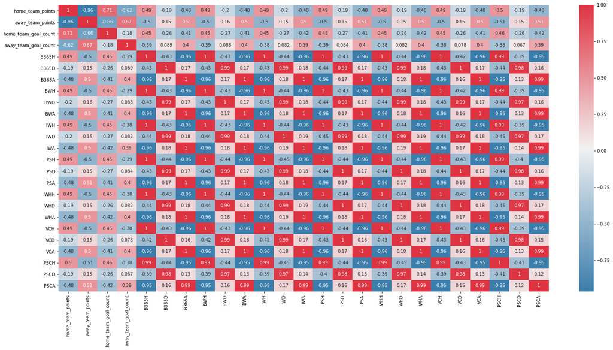

```python
# The heatmap visualisation from the computed matrix
plt.figure(figsize=(25, 12))
cmap = sb.diverging_palette(240,10,s=80,n=9,as_cmap=True)
sb.heatmap(corrmat_bets, annot=True, cmap=cmap)
plt.show()
```

The matrix shows uniform correlations of betting odds and match results. We expected that the correlation values would be higher between the probabilities of the betting companies and the real results of the matches.

In next step, we group the probability columns of individual betting companies to find out the range of margin that they add to each odds.

```python
# For each row, we calculate the sum of probabilities of each betting company
df_bets = df_bets[cols]
df_bets = df_bets.T.groupby([s[:-1] for s in df_bets.T.index.values]).sum().T
df_bets
```

|  | B365 | BW | IW | PS | PSC | VC | WH |
| --- | --- | --- | --- | --- | --- | --- | --- |
| 0 | 1.026686 | 1.036928 | 1.051176 | 1.020698 | 1.020901 | 1.029800 | 1.066767 |
| 1 | 1.032321 | 1.048872 | 1.056583 | 1.021978 | 1.023357 | 1.026718 | 1.063463 |
| 2 | 1.026316 | 1.047706 | 1.055933 | 1.022923 | 1.021689 | 1.023063 | 1.059274 |
| 3 | 1.027451 | 1.050177 | 1.058680 | 1.022351 | 1.022365 | 1.027451 | 1.068336 |
| 4 | 1.024964 | 1.053353 | 1.056452 | 1.022046 | 1.024197 | 1.021130 | 1.065767 |
| ... | ... | ... | ... | ... | ... | ... | ... |
| 375 | 1.026807 | 1.048407 | 1.056071 | 1.031546 | 1.032840 | 1.030100 | 1.047921 |
| 376 | 1.026005 | 1.050909 | 1.053880 | 1.037171 | 1.037234 | 1.026103 | 1.053846 |
| 377 | 1.022618 | 1.052683 | 1.053404 | 1.032717 | 1.034280 | 1.040266 | 1.049812 |
| 378 | 1.025974 | 1.047619 | 1.055438 | 1.025641 | 1.026991 | 1.032175 | 1.047619 |
| 379 | 1.023611 | 1.047396 | 1.049081 | 1.025812 | 1.026256 | 1.028904 | 1.047396 |

380 rows × 7 columns

We calculate the mean of total probabilities.

```python
df_bets.mean(axis = 0).sort_values(ascending=True)
```

```
PSC     1.023505
PS      1.023678
VC      1.026103
B365    1.027788
BW      1.050185
WH      1.052180
IW      1.053489
dtype: float64
```

We see that the sum of the home win odds, draw odds, and away odds are slightly above 100 per cent. That is the margin that each betting company adds to individual odds and it ranges from 2.35-5.34% on average. The most favourable odds for the clients offers the PSC company, the worst odds offers IW company.

# Part 2

In the second part of the analysis, we will try to analyse the relationships between individual game statistics and the final game results by using correlation matrix and logistic regression model.

```python
# list of columns with the game statistics
cols_stats = ['home_team_name','away_team_name','home_team_points', 'away_team_points','home_team_goal_count','away_team_goal_count',
        'home_team_goal_count_half_time','away_team_goal_count_half_time', 'home_team_goal_timings',
        'away_team_goal_timings', 'home_team_corner_count', 'away_team_corner_count', 'home_team_yellow_cards',
        'home_team_red_cards', 'away_team_yellow_cards', 'away_team_red_cards','home_team_first_half_cards',
        'home_team_second_half_cards','away_team_first_half_cards', 'away_team_second_half_cards',
        'home_team_shots', 'away_team_shots', 'home_team_shots_on_target','away_team_shots_on_target',
        'home_team_fouls', 'away_team_fouls', 'home_team_possession', 'away_team_possession',
        'average_goals_per_match_pre_match', 'btts_percentage_pre_match', 'average_corners_per_match_pre_match',
        'average_cards_per_match_pre_match']

# creating a new df with selected columns
df_stats = df[cols_stats].copy()
```

```python
# calculating the Pearson's correlation matrix.
corrmat_stats = df_stats.corr()
corrmat_stats
```

|  | home_team_points | away_team_points | home_team_goal_count | away_team_goal_count | home_team_goal_count_half_time | away_team_goal_count_half_time | home_team_corner_count | away_team_corner_count | home_team_yellow_cards | home_team_red_cards | ... | home_team_shots_on_target | away_team_shots_on_target | home_team_fouls | away_team_fouls | home_team_possession | away_team_possession | average_goals_per_match_pre_match | btts_percentage_pre_match | average_corners_per_match_pre_match | average_cards_per_match_pre_match |
| --- | --- | --- | --- | --- | --- | --- | --- | --- | --- | --- | --- | --- | --- | --- | --- | --- | --- | --- | --- | --- | --- |
| home_team_points | 1.000000 | -0.958568 | 0.708794 | -0.616984 | 0.455571 | -0.405882 | 0.102758 | -0.088299 | -0.121716 | -0.136910 | ... | 0.414478 | -0.426741 | -0.080187 | -0.025937 | 0.221334 | -0.221334 | 0.071190 | -0.042743 | -0.013865 | -0.130051 |
| away_team_points | -0.958568 | 1.000000 | -0.659010 | 0.665349 | -0.428309 | 0.444847 | -0.124823 | 0.097017 | 0.120623 | 0.152517 | ... | -0.390777 | 0.446765 | 0.080963 | -0.002893 | -0.241743 | 0.241743 | -0.080418 | 0.033834 | 0.021062 | 0.125616 |
| home_team_goal_count | 0.708794 | -0.659010 | 1.000000 | -0.178097 | 0.694242 | -0.078393 | 0.084437 | -0.135335 | -0.115578 | -0.058880 | ... | 0.593320 | -0.191037 | -0.061538 | -0.061511 | 0.235736 | -0.235736 | 0.041000 | -0.077924 | 0.006717 | -0.149412 |
| away_team_goal_count | -0.616984 | 0.665349 | -0.178097 | 1.000000 | -0.109562 | 0.687816 | -0.143166 | 0.035768 | 0.157777 | 0.172951 | ... | -0.136683 | 0.544504 | 0.074527 | -0.029490 | -0.222354 | 0.222354 | -0.056857 | 0.018600 | 0.039801 | 0.092055 |
| home_team_goal_count_half_time | 0.455571 | -0.428309 | 0.694242 | -0.109562 | 1.000000 | -0.016028 | -0.062192 | -0.022732 | -0.108617 | 0.011225 | ... | 0.362062 | -0.110836 | -0.050729 | 0.029291 | 0.081064 | -0.081064 | -0.027884 | -0.106874 | -0.048391 | -0.181993 |
| away_team_goal_count_half_time | -0.405882 | 0.444847 | -0.078393 | 0.687816 | -0.016028 | 1.000000 | -0.090209 | -0.032805 | 0.121082 | 0.124112 | ... | -0.050411 | 0.377908 | 0.080572 | 0.004550 | -0.111653 | 0.111653 | -0.041254 | -0.021464 | 0.002237 | 0.066407 |
| home_team_corner_count | 0.102758 | -0.124823 | 0.084437 | -0.143166 | -0.062192 | -0.090209 | 1.000000 | -0.394998 | -0.133670 | -0.037201 | ... | 0.401421 | -0.279580 | -0.110946 | -0.014920 | 0.496215 | -0.496215 | 0.062149 | 0.039139 | -0.011538 | -0.006772 |
| away_team_corner_count | -0.088299 | 0.097017 | -0.135335 | 0.035768 | -0.022732 | -0.032805 | -0.394998 | 1.000000 | 0.120323 | 0.045436 | ... | -0.313882 | 0.291814 | 0.017665 | -0.077330 | -0.477589 | 0.477589 | -0.021383 | 0.026308 | 0.012761 | 0.084903 |
| home_team_yellow_cards | -0.121716 | 0.120623 | -0.115578 | 0.157777 | -0.108617 | 0.121082 | -0.133670 | 0.120323 | 1.000000 | 0.022156 | ... | -0.114989 | 0.147882 | 0.347943 | 0.079188 | -0.157730 | 0.157730 | 0.063185 | 0.134700 | 0.029978 | 0.085213 |
| home_team_red_cards | -0.136910 | 0.152517 | -0.058880 | 0.172951 | 0.011225 | 0.124112 | -0.037201 | 0.045436 | 0.022156 | 1.000000 | ... | -0.099070 | 0.151789 | 0.026826 | -0.039338 | -0.081259 | 0.081259 | -0.088166 | -0.099266 | -0.043789 | -0.041945 |
| away_team_yellow_cards | -0.029551 | 0.008678 | -0.039273 | 0.026434 | 0.028733 | 0.039742 | 0.045789 | -0.099956 | 0.140097 | 0.011455 | ... | 0.005739 | -0.057259 | 0.081916 | 0.339369 | 0.054428 | -0.054428 | -0.002189 | 0.023081 | -0.039329 | -0.020544 |
| away_team_red_cards | 0.036021 | -0.048121 | 0.003761 | -0.051326 | 0.003454 | 0.017016 | 0.050428 | -0.045923 | 0.032744 | 0.028190 | ... | 0.017432 | 0.033412 | 0.033033 | 0.062635 | 0.063458 | -0.063458 | 0.002604 | 0.060997 | -0.029272 | 0.035942 |
| home_team_first_half_cards | -0.084717 | 0.078589 | -0.044775 | 0.146482 | -0.095586 | 0.111597 | -0.034359 | -0.006241 | 0.573264 | 0.080757 | ... | -0.025691 | 0.079212 | 0.234888 | 0.062484 | -0.008305 | 0.008305 | 0.066216 | 0.124768 | 0.065525 | 0.107219 |
| home_team_second_half_cards | -0.112798 | 0.119205 | -0.118365 | 0.118504 | -0.058329 | 0.089749 | -0.143194 | 0.158519 | 0.787101 | 0.175557 | ... | -0.139949 | 0.151338 | 0.251975 | 0.041308 | -0.200275 | 0.200275 | 0.009211 | 0.050044 | -0.020942 | 0.015339 |
| away_team_first_half_cards | 0.076290 | -0.098317 | 0.032009 | -0.055578 | 0.112751 | -0.002980 | 0.090190 | -0.150752 | 0.090434 | -0.021492 | ... | 0.086692 | -0.126481 | 0.046203 | 0.208106 | 0.074747 | -0.074747 | -0.020594 | -0.001213 | -0.082462 | -0.094846 |
| away_team_second_half_cards | -0.081609 | 0.071024 | -0.068010 | 0.058517 | -0.050637 | 0.052230 | -0.001907 | -0.013626 | 0.101377 | 0.036600 | ... | -0.053814 | 0.037868 | 0.067906 | 0.249423 | 0.022971 | -0.022971 | 0.013601 | 0.043309 | 0.009051 | 0.056908 |
| home_team_shots | 0.325111 | -0.322684 | 0.397625 | -0.164030 | 0.224588 | -0.064562 | 0.535195 | -0.428096 | -0.159434 | -0.153588 | ... | 0.761304 | -0.312608 | -0.148609 | -0.006800 | 0.529764 | -0.529764 | 0.039447 | -0.014269 | -0.059618 | -0.073853 |
| away_team_shots | -0.287819 | 0.310590 | -0.185020 | 0.363367 | -0.095323 | 0.227492 | -0.373042 | 0.461444 | 0.154955 | 0.139008 | ... | -0.252668 | 0.744171 | 0.150801 | -0.049570 | -0.473405 | 0.473405 | -0.021513 | 0.044338 | 0.021642 | 0.082757 |
| home_team_shots_on_target | 0.414478 | -0.390777 | 0.593320 | -0.136683 | 0.362062 | -0.050411 | 0.401421 | -0.313882 | -0.114989 | -0.099070 | ... | 1.000000 | -0.182729 | -0.080195 | -0.061624 | 0.444163 | -0.444163 | 0.020811 | -0.058004 | -0.044026 | -0.099641 |
| away_team_shots_on_target | -0.426741 | 0.446765 | -0.191037 | 0.544504 | -0.110836 | 0.377908 | -0.279580 | 0.291814 | 0.147882 | 0.151789 | ... | -0.182729 | 1.000000 | 0.149442 | -0.022266 | -0.311165 | 0.311165 | -0.033442 | 0.025722 | -0.004922 | 0.035799 |
| home_team_fouls | -0.080187 | 0.080963 | -0.061538 | 0.074527 | -0.050729 | 0.080572 | -0.110946 | 0.017665 | 0.347943 | 0.026826 | ... | -0.080195 | 0.149442 | 1.000000 | 0.117220 | -0.230565 | 0.230565 | 0.014544 | 0.088633 | -0.065565 | 0.044773 |
| away_team_fouls | -0.025937 | -0.002893 | -0.061511 | -0.029490 | 0.029291 | 0.004550 | -0.014920 | -0.077330 | 0.079188 | -0.039338 | ... | -0.061624 | -0.022266 | 0.117220 | 1.000000 | 0.105227 | -0.105227 | -0.057697 | -0.014720 | -0.126583 | 0.019018 |
| home_team_possession | 0.221334 | -0.241743 | 0.235736 | -0.222354 | 0.081064 | -0.111653 | 0.496215 | -0.477589 | -0.157730 | -0.081259 | ... | 0.444163 | -0.311165 | -0.230565 | 0.105227 | 1.000000 | -1.000000 | -0.016166 | -0.070984 | -0.081970 | -0.175229 |
| away_team_possession | -0.221334 | 0.241743 | -0.235736 | 0.222354 | -0.081064 | 0.111653 | -0.496215 | 0.477589 | 0.157730 | 0.081259 | ... | -0.444163 | 0.311165 | 0.230565 | -0.105227 | -1.000000 | 1.000000 | 0.016166 | 0.070984 | 0.081970 | 0.175229 |
| average_goals_per_match_pre_match | 0.071190 | -0.080418 | 0.041000 | -0.056857 | -0.027884 | -0.041254 | 0.062149 | -0.021383 | 0.063185 | -0.088166 | ... | 0.020811 | -0.033442 | 0.014544 | -0.057697 | -0.016166 | 0.016166 | 1.000000 | 0.819576 | 0.598490 | 0.508431 |
| btts_percentage_pre_match | -0.042743 | 0.033834 | -0.077924 | 0.018600 | -0.106874 | -0.021464 | 0.039139 | 0.026308 | 0.134700 | -0.099266 | ... | -0.058004 | 0.025722 | 0.088633 | -0.014720 | -0.070984 | 0.070984 | 0.819576 | 1.000000 | 0.420521 | 0.469434 |
| average_corners_per_match_pre_match | -0.013865 | 0.021062 | 0.006717 | 0.039801 | -0.048391 | 0.002237 | -0.011538 | 0.012761 | 0.029978 | -0.043789 | ... | -0.044026 | -0.004922 | -0.065565 | -0.126583 | -0.081970 | 0.081970 | 0.598490 | 0.420521 | 1.000000 | 0.423716 |
| average_cards_per_match_pre_match | -0.130051 | 0.125616 | -0.149412 | 0.092055 | -0.181993 | 0.066407 | -0.006772 | 0.084903 | 0.085213 | -0.041945 | ... | -0.099641 | 0.035799 | 0.044773 | 0.019018 | -0.175229 | 0.175229 | 0.508431 | 0.469434 | 0.423716 | 1.000000 |

28 rows × 28 columns

We will use the heatmap to get a visualisation of all correlations.

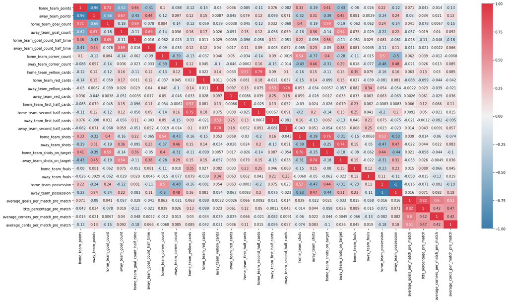

```python
# creating a heatmap by using Seaborn and Matplotlib libraries
plt.figure(figsize=(25, 12))
cmap = sb.diverging_palette(240,10,s=80,n=9,as_cmap=True)
sb.heatmap(corrmat_stats, annot=True, cmap=cmap)
plt.show()
```

The heatmap shows where the relationship between two variables from the data set is strong or weak. We can see several correlations. A weak correlation is between the number of points and the number of corners or ball possession percentage. The number of corners and the ball possession correlates with shots on target. Shots on target correlate with the number of goals. The strongest correlation is between goals and points. Scored goals have a positive correlation with the points and conceded goals have a negative correlation. Therefore, the ratio between scored goals scored and conceded goals will have a better correlation with the final points. We can calculate this ratio and add it to our data set.

```python
# calculation the ratio of goals scored and goals conceded
goal_ratio = df_stats["home_team_goal_count"]/df_stats["away_team_goal_count"]
goal_ratio
```

```
0      2.00
1      0.50
2       inf
3      0.00
4      0.00
       ...
375     inf
376    0.00
377    1.00
378    1.00
379    0.25
Length: 380, dtype: float64
```

Since it is very common to have zero goals, we get a lot of infinite values in the goal ratio column. Therefore, we adjust the calculation by adding +1 goal on both sides of the goal count.

```python
# adding a new column to our dataset with the calculated ratio
goal_ratio = (df_stats["home_team_goal_count"]+1)/ (df_stats["away_team_goal_count"]+1)
df_stats["goal_ratio"] = goal_ratio
```

```python
# selecting all relevant columns for the correlation matrix
df_stats_corr = df_stats[["home_team_points","away_team_points","home_team_goal_count","away_team_goal_count","goal_ratio"]]
```

```python
corrmat_stats = df_stats_corr.corr()
corrmat_stats
```

|  | home_team_points | away_team_points | home_team_goal_count | away_team_goal_count | goal_ratio |
| --- | --- | --- | --- | --- | --- |
| home_team_points | 1.000000 | -0.958568 | 0.708794 | -0.616984 | 0.770731 |
| away_team_points | -0.958568 | 1.000000 | -0.659010 | 0.665349 | -0.724727 |
| home_team_goal_count | 0.708794 | -0.659010 | 1.000000 | -0.178097 | 0.724252 |
| away_team_goal_count | -0.616984 | 0.665349 | -0.178097 | 1.000000 | -0.637267 |
| goal_ratio | 0.770731 | -0.724727 | 0.724252 | -0.637267 | 1.000000 |

The correlation between goal ratio and team_points is higher than the correlation between goal count and team points. It appears to be a piece of useful statistical information in the relation to the performance of a team.

## Multinomial Logistic Regression

To understand the nature of individual features, we will try to find a regression model that will sufficiently describe the correlations among individual statistics and their relationship on the game result. We tried to fit individual game statistics into linear regression model, but that approach lead to two problems:

- problem to identify continuous dependant feature that describe the game result
- distributed y values relative to the regression line

```python
# a linear approximation of the data
x_col = "home_team_shots_on_target"
y_col = "home_team_points"

X = df[x_col].values.reshape(-1,1)
y = df[y_col].values.reshape(-1,1)

model = linear_model.LinearRegression()
model.fit(X,y)
predictions = model.predict(X)
```

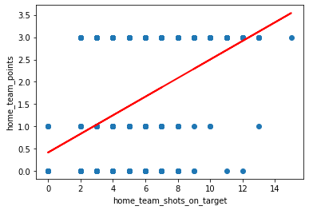

```python
# a scatter plot for the linear regression model
%matplotlib inline
plt.scatter(X,y)
plt.plot(X,predictions, c='red', linewidth=2)

plt.xlabel(x_col)
plt.ylabel(y_col)
```

The graph shows that the relationship of the independent and dependant variable is not linear and we cannot fit a linear regression line into this data. We have ternary categorical data in our dataset for the number of points scored for the game. (3 points for a win, 0 points for a loss, 1 for a draw). When the dependent variable consists of several categories the logistic regression model should be used. We use a multinomial logistic regression model for fitting selected independent variables.

### Selecting relevant features

We select suitable candidates for independent variables in the regression model. And then we create multiple regression models with various combinations of these variables.

```python
# maping of the column names for better column selection
A = "home_team_goal_count_half_time"
B = "away_team_goal_count_half_time"
C = "home_team_corner_count"
D = "away_team_corner_count"
E = "home_team_red_cards"
F = "away_team_red_cards"
G = "home_team_shots"
H = "away_team_shots"
I = "home_team_shots_on_target"
J = "away_team_shots_on_target"
K = "home_team_possession"
L ="away_team_possession"
```

```python
# selecting features for the regression model
cols = [A,B,I,J,K]
# indepedent values
X = df[cols].values
# dependent values
y = df_stats["home_team_points"].values

X.shape, y.shape
```

```
((380, 5), (380,))
```

```python
# creating the multinomial regression model, training the model
model = linear_model.LogisticRegression(solver='lbfgs', max_iter=400, multi_class='multinomial')
model.fit(X,y)
```

```
LogisticRegression(max_iter=400, multi_class='multinomial')
```

```python
# print model parameters
print('Intercept: \n', model.intercept_)
print('Cofficients: \n', model.coef_)
```

```
Intercept:
 [-0.08336163 -0.27807538  0.36143701]
Cofficients:
 [[-1.00529139  0.96776703 -0.15719022  0.22825724 -0.00690636]
 [ 0.05235364 -0.22911494 -0.06469116 -0.02027466  0.01353684]
 [ 0.95293775 -0.73865209  0.22188138 -0.20798259 -0.00663047]]
```

### Assesment of the regression model

We use the statsmodels library to get regression results from the model.

```python
# regression results calculated by the statsmodels library
logit_model=sm.MNLogit(y, sm.add_constant(X))
result=logit_model.fit()
stats1=result.summary()
stats2=result.summary2()
print(stats1)
print(stats2)
```

```
Optimization terminated successfully.
         Current function value: 0.684530
         Iterations 7
                          MNLogit Regression Results
==============================================================================
Dep. Variable:                      y   No. Observations:                  380
Model:                        MNLogit   Df Residuals:                      368
Method:                           MLE   Df Model:                           10
Date:                Thu, 07 Jan 2021   Pseudo R-squ.:                  0.3375
Time:                        21:21:13   Log-Likelihood:                -260.12
converged:                       True   LL-Null:                       -392.63
Covariance Type:            nonrobust   LLR p-value:                 3.762e-51
==============================================================================
       y=1       coef    std err          z      P>|z|      [0.025      0.975]
------------------------------------------------------------------------------
const         -0.1758      0.878     -0.200      0.841      -1.897       1.546
x1             1.1614      0.334      3.475      0.001       0.506       1.816
x2            -1.2563      0.268     -4.689      0.000      -1.781      -0.731
x3             0.0948      0.082      1.162      0.245      -0.065       0.255
x4            -0.2517      0.085     -2.950      0.003      -0.419      -0.084
x5             0.0205      0.014      1.463      0.144      -0.007       0.048
------------------------------------------------------------------------------
       y=3       coef    std err          z      P>|z|      [0.025      0.975]
------------------------------------------------------------------------------
const          0.4450      0.885      0.503      0.615      -1.289       2.179
x1             2.0889      0.327      6.380      0.000       1.447       2.731
x2            -1.8025      0.285     -6.316      0.000      -2.362      -1.243
x3             0.3821      0.083      4.598      0.000       0.219       0.545
x4            -0.4403      0.089     -4.964      0.000      -0.614      -0.266
x5             0.0005      0.014      0.034      0.973      -0.027       0.028
==============================================================================
                        Results: MNLogit
=================================================================
Model:              MNLogit          Pseudo R-squared: 0.337
Dependent Variable: y                AIC:              544.2427
Date:               2021-01-07 21:21 BIC:              591.5248
No. Observations:   380              Log-Likelihood:   -260.12
Df Model:           10               LL-Null:          -392.63
Df Residuals:       368              LLR p-value:      3.7625e-51
Converged:          1.0000           Scale:            1.0000
No. Iterations:     7.0000
-----------------------------------------------------------------
y = 0    Coef.    Std.Err.      t      P>|t|     [0.025    0.975]
-----------------------------------------------------------------
const   -0.1758     0.8784   -0.2002   0.8414   -1.8974    1.5458
   x1    1.1614     0.3342    3.4752   0.0005    0.5064    1.8164
   x2   -1.2563     0.2679   -4.6888   0.0000   -1.7815   -0.7312
   x3    0.0948     0.0816    1.1619   0.2453   -0.0651    0.2548
   x4   -0.2517     0.0853   -2.9499   0.0032   -0.4189   -0.0845
   x5    0.0205     0.0140    1.4626   0.1436   -0.0070    0.0480
-----------------------------------------------------------------
y = 1    Coef.    Std.Err.      t      P>|t|     [0.025    0.975]
-----------------------------------------------------------------
const    0.4450     0.8847    0.5030   0.6150   -1.2890    2.1790
   x1    2.0889     0.3274    6.3795   0.0000    1.4471    2.7306
   x2   -1.8025     0.2854   -6.3165   0.0000   -2.3618   -1.2432
   x3    0.3821     0.0831    4.5979   0.0000    0.2192    0.5450
   x4   -0.4403     0.0887   -4.9643   0.0000   -0.6142   -0.2665
   x5    0.0005     0.0142    0.0336   0.9732   -0.0273    0.0282
=================================================================
```

```python
# we calculate the probability score of the model
model.score(X,y)
```

```
0.7026315789473684
```

We created a set of models, each containing a different combination of game statistics. In the table, we compared these models according to the following criteria:

- probability score
- p-values
- Pseudo R^2
- AIC

**Figure 1** Feature combinations with the resulting logistic probability score from the logistic regression model

| **Model** | **A** | **B** | **C** | **D** | **E** | **F** | **G** | **H** | **I** | **J** | **K** | **L** | **score** | **AIC** | **Pseudo R^2** |
| --- | --- | --- | --- | --- | --- | --- | --- | --- | --- | --- | --- | --- | --- | --- | --- |
| 1 |  | o |  |  | o |  |  |  |  | o |  |  | 0.50 | 674.570 | 0.161 |
| 2 |  |  |  |  | o | o |  |  |  | o |  |  | 0.52 | 712.349 | 0.113 |
| 3 |  |  |  |  | o |  |  | o |  | o |  |  | 0.54 | 713.532 | 0.112 |
| 4 |  |  |  |  |  | o | o |  |  | o |  |  | 0.55 | 695.340 | 0.135 |
| 5 |  | o |  |  | o |  |  | o |  | o |  |  | 0.57 | 677.624 | 0.163 |
| 6 |  |  |  |  |  |  |  |  | o | o |  |  | 0.62 | 653.827 | 0.183 |
| 7 |  |  | o |  |  |  |  |  | o | o | o |  | 0.63 | 644.388 | 0.204 |
| 8 |  |  | o |  |  | o |  |  | o | o | o |  | 0.63 | 644.960 | 0.209 |
| 9 | o |  |  |  |  |  |  |  | o | o |  |  | 0.67 | 596.408 | 0.260 |
| 10 | o | o |  |  |  |  | o | o | o | o | o | o | 0.68 | 553.778 | 0.340 |
| 11 | o |  |  |  | o |  |  |  | o | o | o |  | 0.68 | 598.175 | 0.269 |
| 12 | o | o |  |  |  |  |  |  | o | o | o |  | 0.70 | 544.242 | 0.337 |
| 13 | o | o |  |  |  |  |  |  | o | o | o | o | 0.70 | 548.242 | 0.337 |
| 14 | o | o |  |  |  |  | o |  | o | o | o | o | 0.70 | 551.807 | 0.338 |
| 15 | o | o |  |  |  | o |  |  | o | o | o | o | 0.70 | 548.521 | 0.342 |

Independent variables:

- A - home_team_goal_count_half_time
- B - away_team_goal_count_half_time
- C - home_team_corner_count
- D - away_team_corner_count
- E - home_team_red_cards
- F - away_team_red_cards
- G - home_team_shots
- H - away_team_shots
- I - home_team_shots_on_target
- J - away_team_shots_on_target
- K - home_team_possession
- L - away_team_possession

### Splitting Data

We split the data into a training dataset and test dataset. Training data will train the model and test data will be used to test the model performance.

```python
# 90 % of data will be used for training, 10 % for testing.
x_train, x_test, y_train, y_test = train_test_split(X, y, test_size=0.10)
```

```python
x_train.shape, x_test.shape
```

```
((342, 5), (38, 5))
```

### Creating Model

Next, we create a training model and fit it with the training data.

```python
# instantiate the model with specified optimization algo and increased number of iterations
model = linear_model.LogisticRegression(solver='lbfgs', max_iter=400, multi_class='multinomial')
# fit the model with the data
model.fit(x_train, y_train)
```

```
LogisticRegression(max_iter=400, multi_class='multinomial')
```

Now we can use the model to predict the results on the test dataset.

```python
y_predicted = model.predict(x_test)
```

### Prediction Model evaluation

```python
model.score(x_train, y_train)
```

```
0.695906432748538
```

Finally, we will present the results in the confusion matrix.

```python
# show the confusion matrix.
cm = confusion_matrix(y_test, y_predicted)
cm
```

```
array([[13,  1,  2],
       [ 3,  0,  1],
       [ 0,  0, 18]])
```

The dimension of the matrix is 3x3 because our model classified features into 3 classes. Diagonal values represent accurate predictions. Let's look at the matrix using the heatmap visualisation.

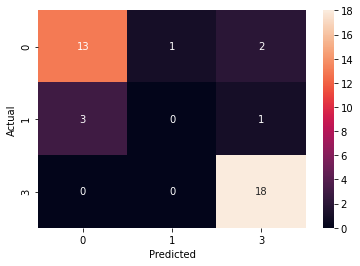

```python
# show the matrix visualisation using heatmap
c_matrix = pd.crosstab(y_test, y_predicted, rownames=['Actual'], colnames=['Predicted'])
sb.heatmap(c_matrix, annot=True)
```

```python
# convert to the numpy matrix and extract true and false predictions

cm = np.matrix(cm)
total = cm.sum()
total_true = np.trace(cm)
true_losses = cm[0,0]
true_draws = cm[1,1]
true_wins = cm[2,2]
false_losses = cm[0,2] + cm[0,1]
false_draws = cm[0,1] + cm[2,1]
false_wins = cm[0,2] + cm[2,2]
total_false = total - total_true
print("The matrix shows that the model correctly predicted {} wins, {} draws and {} losses from total of {} games.".format(true_wins,true_draws,true_losses, total))

print("Incorrect predictions were {}. False wins: {}. False draws: {}. False losses: {}. ".format(total_false, false_wins, false_draws, false_losses))
```

```
The matrix shows that the model correctly predicted 18 wins, 0 draws and 13 losses from total of 38 games.
Incorrect predictions were 7. False wins: 20. False draws: 1. False losses: 3.
```

```python
accuracy_score = metrics.accuracy_score(y_test, y_predicted)
print('Accuracy Score: ', int(accuracy_score*100),'%')
```

```
Accuracy Score:  81 %
```

We calculated the accuracy score. It measures the proportion of correct predictions over total predictions. To objectively measure the performance of this model, we could compare it a with another model trained on the same data. For the unbiased evaluation of the model, the validation dataset could be used. We should also consider the larger dataset for training, for example, data from multiple seasons.

## Conclusion

When we want to analyze football statistics and their relationship to team performance, we have to take many factors into account.

We were able to identify which statistics from the dataset correlate the most with the team's performance. We tested several combinations to obtain the regression model with the highest accuracy.

We also analyzed the betting odds and their relationship to the game results. We have calculated the average margin that betting companies add to the odds and which betting company offers the best odds.

## For futher work

We only looked at a small range of relevant game statistics. If we were able to collect more detailed data about offensive, defensive or players statistics, more accurate data analysis could be made.

## References and Resources

FootyStats. 2020. [online] Available at: https://footystats.org/england/premier-league# [Accessed 13 December 2020]

Football-Data.co.uk. 2020. [online] Available at: https://www.football-data.co.uk/englandm.php [Accessed 14 December 2020]

Chaurasia A., Harel. O. (2013). Using AIC in Multiple Linear Regression framework with Multiply Imputed Data. [online] Available at: https://www.ncbi.nlm.nih.gov/pmc/articles/PMC3412358/ [Accessed 19 December 2020].

Anderson, Faye. (2016). Re: What is the relationship between R-squared and p-value in a regression?. [online] Available at: https://www.researchgate.net/post/What_is_the_relationship_between_R-squared_and_p-value_in_a_regression/57612faddc332d362552c5f1/citation/download [Accessed 20 December 2020].